# How should prior beliefs influence our conclusions from Moran et al. (2020)?

# Is the mind an iceberg or a puddle?

I recently had the opportunity to be involved in Moran, Hughes, Hussey, Valdilo, Olson, et al.’s (2020) Registered Replication Report. This was a replication of Olson & Fazio’s (2001) study on attitude formation via stimulus pairing (Evalautive Conditioning) in the absence of awareness that stimuli had been paired.

A bit of a mouthful, but a key motivator for me was that Olson & Fazio (2001) is (a) highly cited and influential upon later theoretical and empirical work, and yet (b) when you ask them informally, most researchers in the field say they doubt the effect would replicate.

Why?

On the other hand, maybe the human mind is mysterious, deep and just plain cool. Maybe it’s doing all sorts of calculations that we are unaware of and only letting our conscious mind in on some of it. By implication, maybe you do have the hidden depth that your existential dread yearns for. More specifically, maybe there are participants who now think “CUG” is negative despite being unaware that it was ever paired with “Cancer”. This would allow us to think and talk about things like “low level cognitive processes” that are “automatic” or “occur outside of awareness”, or other validations of our collective need for quasi religious mystery in psychology. It is, as commentators in the 2015 US presidential campaign used to say, “Big, if true”.

Perhaps by this stage you have some idea of which camp I’m in.

At this point, as a reader, maybe its tempting to think that I am being biased here. I whole heartedly agree, and don’t think this is a bad thing.

Here’s were the benefits of Bayesian statistics come in: prior beliefs - the lense through which we interpret new data - can be quantified; we can examine their impact on conclusions; and we can consider more than one. For example, we can formalize how a true believer in Unaware Evalautive Conditioning vs. a hardline skeptic should each interpret the results of Moran et al. (2020).

This isn’t attempt to be ‘free of bias’ - an idea that appeals to a false sense of attainable objectivity and scientism - but instead allows us to explicate our prior beliefs and integrate them into our analysis and conclusions. It also allows you to see the same data through the lens of others’ beliefs.

# Bayesian analysis and defining priors

The process of choosing priors is something many people initially find difficult when learning Bayesian analysis.

There was another key feature of this project that got me interested in it: the draft manuscript already contained a meta analysis of the published literature.

Personally, I think a reasonable way to choose priors is to look to the existing published literature. This isn’t to say that the published literature is unbiased - it almost definitely is, as multiple large scale repliation effects in the last few years have [shown us](https://www.frontiersin.org/articles/10.3389/fpsyg.2019.00813/full). Nonetheless, the literature gives us a starting point.

Creating priors using posteriors from published literature…

NB all use Sigma = cauchy(location = 0.00, scaling = 0.50) for the sd of the random effect for site.

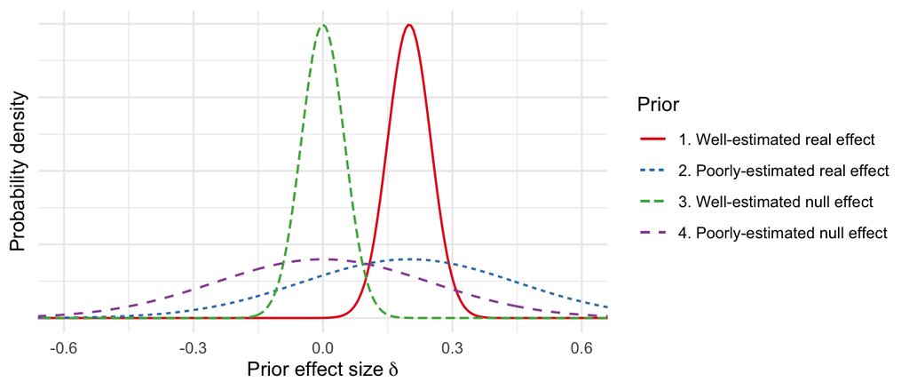

# Power analyses

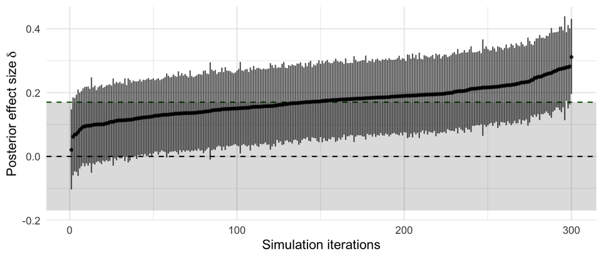

| true_effect | prior | mean_estimate | sd_estimate | power_null_test | power_rope_test | power_esimation |
| --- | --- | --- | --- | --- | --- | --- |
| 0.17 | Well-estimated real effect | 0.19 | 0.02 | 1.000 | 0.000 | 0.997 |
| 0.17 | Poorly-estimated real effect | 0.17 | 0.05 | 0.867 | 0.003 | 0.993 |
| 0.17 | Poorly-estimated null effect | 0.17 | 0.05 | 0.860 | 0.003 | 0.990 |
| 0.17 | Well-estimated null effect | 0.07 | 0.02 | 0.093 | 0.937 | 0.063 |
| 0.00 | Well-estimated real effect | 0.13 | 0.02 | 1.000 | 0.000 | 0.000 |
| 0.00 | Poorly-estimated real effect | 0.00 | 0.05 | 0.007 | 0.733 | 0.990 |
| 0.00 | Poorly-estimated null effect | 0.00 | 0.05 | 0.003 | 0.713 | 0.993 |
| 0.00 | Well-estimated null effect | 0.00 | 0.02 | 0.000 | 1.000 | 1.000 |

# Analysis

Using compound exclusion criterion (Hussey & Hughes, 2020)

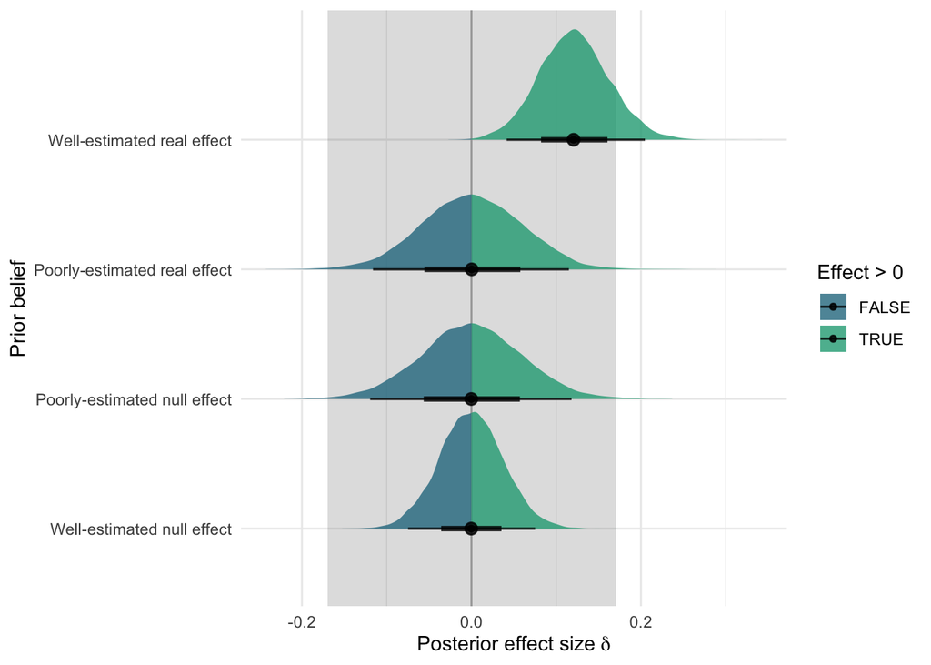

NB 66% and 95% HDIs. ROPE was $\delta$ = -0.17 to 0.17.

| prior | delta_and_hdi | p_greater_zero | p_in_rope | p_less_lit | p_less_orig |
| --- | --- | --- | --- | --- | --- |
| Well-estimated real effect | 0.12 [ 0.04, 0.20] | 0.001 | 0.898 | 0.032 | 0 |
| Poorly-estimated real effect | 0.00 [-0.12, 0.11] | 0.497 | 1.000 | 0.002 | 0 |
| Poorly-estimated null effect | 0.00 [-0.12, 0.12] | 0.498 | 1.000 | 0.001 | 0 |
| Well-estimated null effect | 0.00 [-0.07, 0.08] | 0.497 | 1.000 | 0.000 | 0 |

# Conclusions

- Conclusions reached on the basis of the data do indeed depend on prior beliefs.
- Using 95% HDIs and/or Bayesian *p* values (i.e., 1-posterior probability of direction), the data plus a prior belief in a well-estimated true effect produced a posterior belief that was credibly different from zero. The other three priors did not give rise to a credible posterior effect, and indeed all gave rise to an effect that was 100% within the region of practical equivalence with zero. As such, differences in priors gave rise to differences not only with regard to the support for H1, but also the support for H0: three priors not only fail to find evidence for H1 but find support for H0.
- Critically, however, the prior belief that there is a true effect (i.e., belief in the unaware EC hypothesis) was not sufficent to the posterior belief in the hypothesis: the combination of a prior belief in the effect *and* specificity in its estimation (i.e., relative confidence in the effect size range) was required for a posterior belief in the effect.
- If you believe the results of the meta analysis of published literature, this replication study does not contain enough data to change your mind.
- Equally, if you strongly disbelieve the effect is real, this replication does not contain enough data to change your mind.
- The analyses in Moran et al are null hypothesis tests: is the effect greater than zero.
- Bayesian versions of this show mixed evidence that is sensitive to choice of prior.
- It is also meaningful to ask is the effect greater or smaller than the ES in the published literature.
- Results are a more conclusive yes: Belief in the effect being non zero may be dependant on choice of prior (i.e., only a very strong prior belief in the effect being true allows posterior belief to persist), but posterior belief that the effect is substantially smaller than that found in the published literature is independant of prior.
- As such, results give some small room to continue to believe in the effect if your prior beliefs are very strong, but they leave no doubt that effects are lower than in the published literature.
- One of the original authors, Olson, was involved in the replication.
- Both of the original authors agreed to approve the study protocol prior to registration and data collection.
- It was a multi-site replication with 12 different labs around the world.
- The project provided me with novel challenges around making the materials and analyses maximally reproducible.